# Probabilistic Forecasts

Conventional VARs produce point forecasts. A Bayesian VAR produces a full posterior predictive distribution over future paths. This means every forecast comes with calibrated uncertainty — wide bands when the model is unsure, narrow when the data are informative.

```python
import numpy as np
import pandas as pd

from litterman import VAR, VARData
from litterman.samplers import NUTSSampler
```

## Setup

We repeat the data-generating process from the quickstart tutorial. The DGP is a VAR(1) with three macro variables — GDP growth, inflation, and an interest rate. If you've already worked through that notebook, the setup code below will be familiar.

```python
rng = np.random.default_rng(42)
T = 200
n_vars = 3

A_true = np.array([
    [0.6, 0.0, -0.1],
    [0.2, 0.5, 0.0],
    [0.0, 0.15, 0.4],
])

y = np.zeros((T, n_vars))
for t in range(1, T):
    y[t] = A_true @ y[t - 1] + rng.standard_normal(n_vars) * 0.1

index = pd.date_range("2000-01-01", periods=T, freq="QS")
data = VARData(endog=y, endog_names=["gdp_growth", "inflation", "rate"], index=index)

sampler = NUTSSampler(draws=500, tune=500, chains=2, cores=1, random_seed=42)
fitted = VAR(lags=1, prior="minnesota").fit(data, sampler=sampler)
fitted
```

```
Initializing NUTS using jitter+adapt_diag...
```

[output not shown]

[output not shown]

[output not shown]

```
Sequential sampling (2 chains in 1 job)
```

```
NUTS: [intercept, B, sigma_sd, tril_offdiag]
```

```
Sampling 2 chains for 500 tune and 500 draw iterations (1_000 + 1_000 draws total) took 8 seconds.
```

```
We recommend running at least 4 chains for robust computation of convergence diagnostics
```

```
The rhat statistic is larger than 1.01 for some parameters. This indicates problems during sampling. See https://arxiv.org/abs/1903.08008 for details
```

```
FittedVAR(n_lags=1, n_vars=3, n_draws=500, n_chains=2)
```

## Point forecasts

Call `.forecast(steps=8)` to produce an 8-step-ahead forecast. The result is a `ForecastResult` object that holds the full posterior predictive draws. The `.median()` method extracts the central tendency — the posterior median at each horizon.

```python
fcast = fitted.forecast(steps=8)
fcast.median()
```

|  | gdp_growth | inflation | rate |
| --- | --- | --- | --- |
| 0 | -0.014540 | 0.071661 | -0.053629 |
| 1 | -0.011210 | 0.040612 | -0.027609 |
| 2 | -0.007933 | 0.020123 | -0.014777 |
| 3 | -0.006204 | 0.006955 | -0.008371 |
| 4 | -0.004932 | -0.001477 | -0.005218 |
| 5 | -0.003907 | -0.006338 | -0.003961 |
| 6 | -0.003370 | -0.009685 | -0.003202 |
| 7 | -0.003027 | -0.011824 | -0.002997 |

Each row is a forecast horizon (1 through 8 quarters ahead). The values converge toward the unconditional mean of the process as the horizon increases — a hallmark of stationary VARs.

## Credible intervals

The `.hdi()` method computes the highest density interval at a given probability level. An 89% HDI means 89% of the posterior forecast mass falls within these bounds. We use 89% rather than 95% following the ArviZ convention — it avoids the false precision of round numbers.

```python
hdi = fcast.hdi(prob=0.89)

print("Lower bounds:")
print(hdi.lower)
print("\nUpper bounds:")
print(hdi.upper)
```

```
Lower bounds:
   gdp_growth  inflation      rate
0   -0.031277   0.054359 -0.070959
1   -0.036345   0.016419 -0.051801
2   -0.037510  -0.006688 -0.040389
3   -0.036315  -0.020397 -0.031594
4   -0.036477  -0.033224 -0.028444
5   -0.038981  -0.038691 -0.027536
6   -0.039034  -0.042093 -0.025694
7   -0.036629  -0.044539 -0.026394

Upper bounds:
   gdp_growth  inflation      rate
0    0.002189   0.090009 -0.037232
1    0.012244   0.067507 -0.007752
2    0.019108   0.051113  0.005842
3    0.023985   0.040442  0.014508
4    0.025926   0.030621  0.018512
5    0.024715   0.025776  0.019941
6    0.025601   0.024401  0.021695
7    0.028120   0.023066  0.021521
```

The intervals widen at longer horizons. This is expected: uncertainty compounds over time because each forecast step propagates parameter uncertainty forward.

## Visualise the forecast

The `.plot()` method produces a fan chart showing the median forecast with shaded credible bands for each variable.

```python
fig = fcast.plot()
```

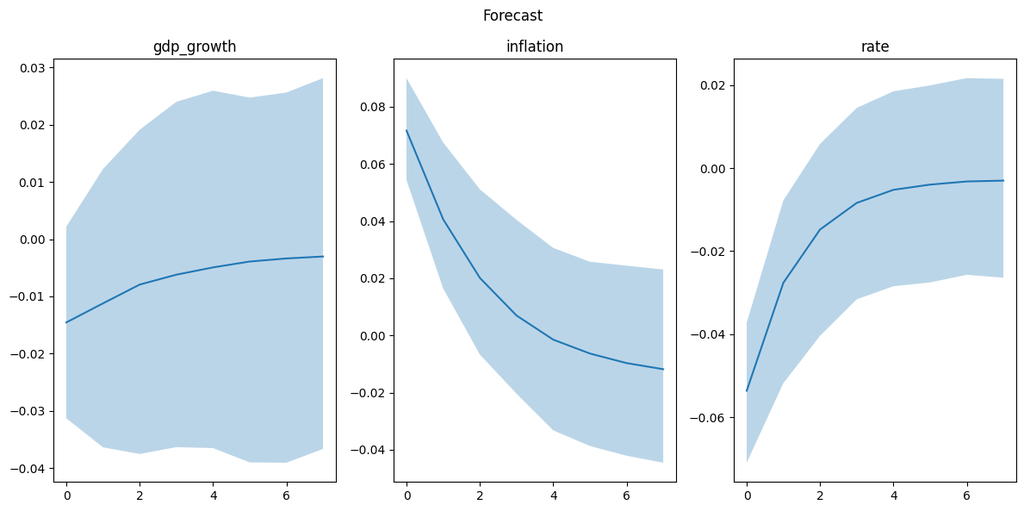

## Tidy export

For downstream analysis or dashboarding, `.to_dataframe()` returns the median forecast in a tidy DataFrame format.

```python
fcast.to_dataframe()
```

| step | gdp_growth | inflation | rate |
| --- | --- | --- | --- |
| 0 | -0.014540 | 0.071661 | -0.053629 |
| 1 | -0.011210 | 0.040612 | -0.027609 |
| 2 | -0.007933 | 0.020123 | -0.014777 |
| 3 | -0.006204 | 0.006955 | -0.008371 |
| 4 | -0.004932 | -0.001477 | -0.005218 |
| 5 | -0.003907 | -0.006338 | -0.003961 |
| 6 | -0.003370 | -0.009685 | -0.003202 |
| 7 | -0.003027 | -0.011824 | -0.002997 |

## Summary

Bayesian VAR forecasts provide more than point predictions. The full posterior predictive distribution lets you quantify and communicate forecast uncertainty honestly. For structural questions — what happens to inflation when the central bank raises rates? — see the Structural Analysis tutorial.